# Incarceration: The Burden to POC Across the U.S.

Ella Uchtmann

11-22-2022

## Abstract

In this report an analysis on **incarceration in the United States** will be done to uncover trends within the data set contributed by the Vera Institute of Justice. There are four data visualizations in the form of a *bar chart*, *line chart*, *scatter plot*, and *Unites States map*, all examining different aspects of the data and represent trends of inequality concerning incarceration.

## Introduction

Incarceration in the United States is a huge *burden* on the shoulders of racial minorities upheld by the those in power. There are many issues surrounding the prison system in the United States. Such as, the disproportionate amount of black people incarcerated. In this report, data from the *Vera Institute of Justice’s Incarceration Trends Data Set*, will be examined and analyzed to further explore inequalities within the United States prison system. **Direct stakeholders** that should be considered when researching this data set are policy makers and government officials. Racism and injustice in the prison system are upheld and reinforced by policies and laws within the U.S.. Change can only truly happen in the hands of well informed people in power through the critical analysis and research of this data. **Indirect stakeholders** that should be considered with extra care are people of color, specifically black people. The decisions made by direct stakeholders based on this data has nearly no daily effect on those in power. It will drastically impact the lives of thousands of P.O.C. people in their everyday lives.

This report specifically summarizes key values within the data, such as the racial groups with the largest and smallest populations within the prison system historically and currently. There are also graphs showing the growth of the prison population by state and the entirety of the U.S. from 1970 to 2018. The final two charts represent inequalities within the U.S. prison system through analysis of the data.

## Data Summary

Through data wrangling I thought it would be insightful to examine the differences between cumulative data across all years and counties with the most recent year of data available. I started with calculating the race with the highest prison population count across all data. The calculation turned out to be **black_prison_pop**. This means that the racial group with the highest prison population across all data is Black people. I then decided to see if this trend holds true to the most recent year. I calculated the race with the current highest prison population and the result was **black_prison_pop**. This shows that Black people continue to hold the highest prison population in the U.S.. I then thought it would be useful to understand the racial group with the lowest prison counts. I calculated the race with the lowest prison population across the whole data set and the result is **aapi_prison_pop**. Just as I did with the highest counts, I decided to calculate the race with the current lowest prison count to see if this trend still exists. The result is **aapi_prison_pop**. This means that AAPI peoples hold the lowest prison population historically and currently as analyzed through this data set.

It is important to take into consideration populations when looking at these results. AAPI and Black peoples make up a relatively small individual chunk of the U.S. population. This explains why the AAPI results were so low. I think this goes to show how powerful these variables truly are. Because, while Black people are still a minority group like AAPI people, they still account for a majority of the prison population despite lesser total population.

## Growth of the U.S. Prison Population

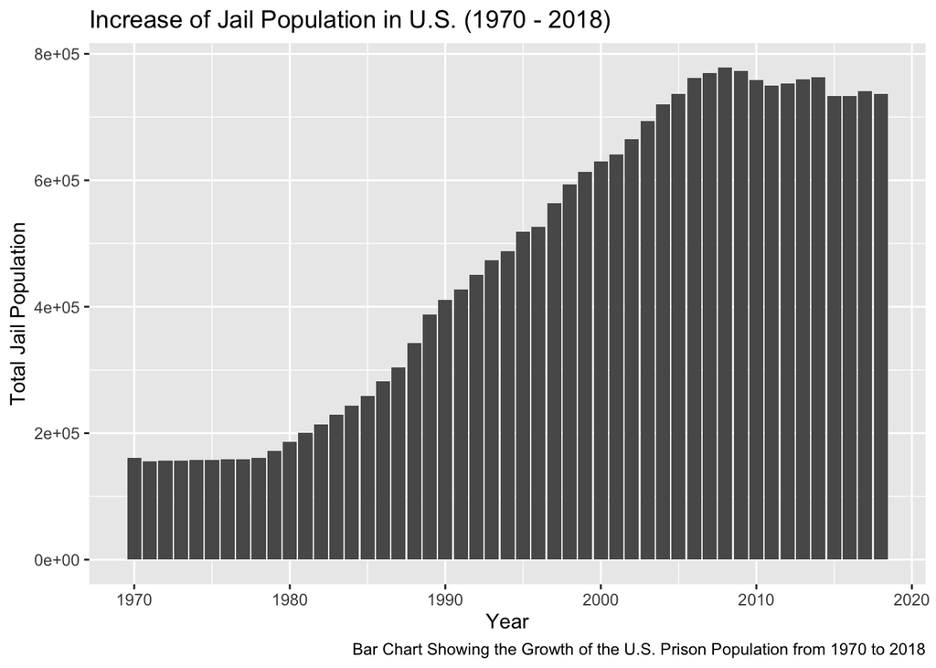

A question that may be answered by this chart is, “*How has the prison population grown or declined*?” As the chart displays, there seems to be a relatively stagnant prison population from the early 1970s to the late 1970s at a population just above 150,000. A linear increase in the population then began in the late 1970s in to the late 2000s. The population then settled at about 750,000 people continuing in to 2018. The pattern revealed by the chart is that there was a relatively steady low prison population in the 1970s. Possible changes in policy, societal views, etc. created a shift of hundreds of thousands of people going into the prison system and then again creating a steady prison population but relatively, extremely high.

## Growth of Prison Population by State

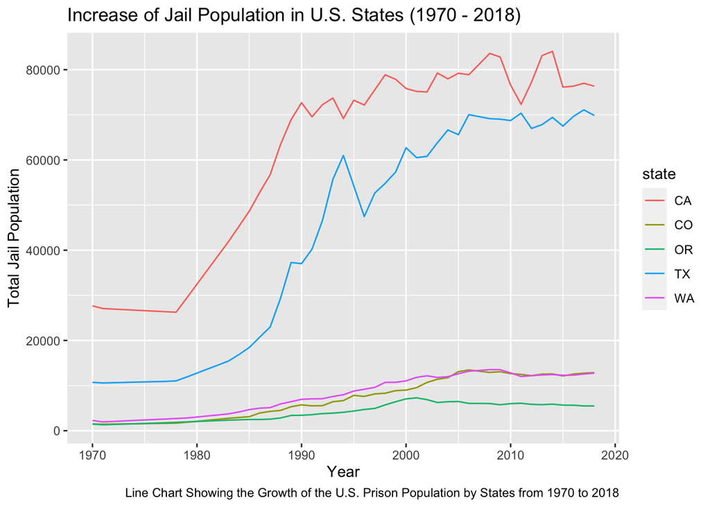

A question that may be answered by this chart is, “*How has the prison population grown and shifted on a state by state basis*? The chart displays five states growth in prison population. The five states are, California(CA), Colorado(CO), Oregon(OR), Texas(TX), and Washington(”WA”). I chose WA, OR, and CA to see how the West Coast may differ from other states. I chose CO due to it’s general location in the Central U.S. I chose TX due to it’s location in the South. Overall, I thought it would be an interesting case study. What is similar about all states is that their initial inclines in growth all happen around 1980. Washington and Colorado have the most similar trends. They start at the same population and then the make progression up until about the same peak. Oregon has a progression up like the rest of the states, but the population is consistently lower and the smoothest trend. However, Washington, Colorado, and Oregon all have smooth lines compared to California and Texas. California and Texas have relatively extreme jumps in population in the 1980s. After the initial peak they both continue to go up and down in population by a significant portion. They both have relatively high prison populations but California is the highest consistently.

## Black and White Prison Population Trends

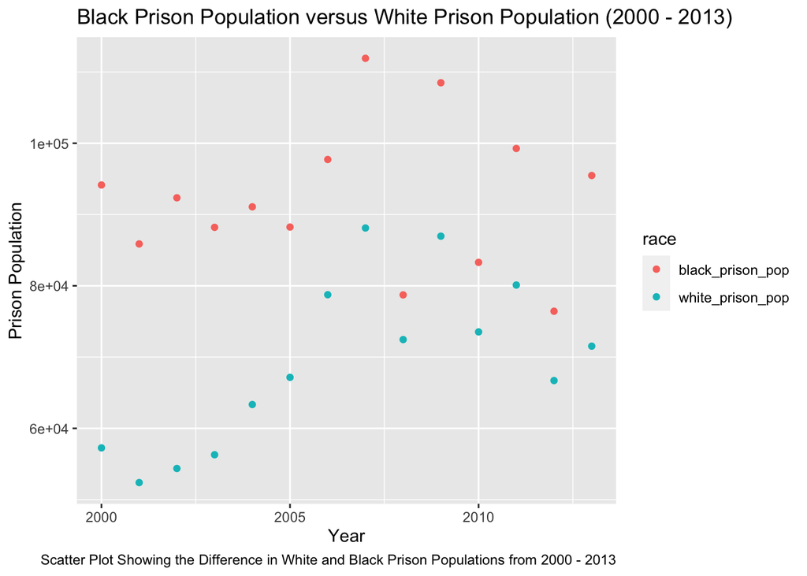

The question inspiring this data visualization was, “*Are there patters between the black prison population and white prison population*?” Patterns revealed through the data visualization continue to prove black people are held in prison at far higher capacities compared to other races. I chose to compare black prison population and white prison population because in a societal context this would be insightful to the climate of today. The chart shows the black prison population to be far higher on the y-axis with the white prison population always lower on the y-axis. What is the most interesting is that despite such large differences in population numbers, the line trend seems to stay similar across the years studied. As it appears, when there is a spike in population in black peoples, a spike also occurs in the white population. When there is a decline in the white population, there is a decline in the black population as well. So, while the black prison population is far higher than the white population, they follow a similar trend.

## Racial Minority Prison Population Percentage by State

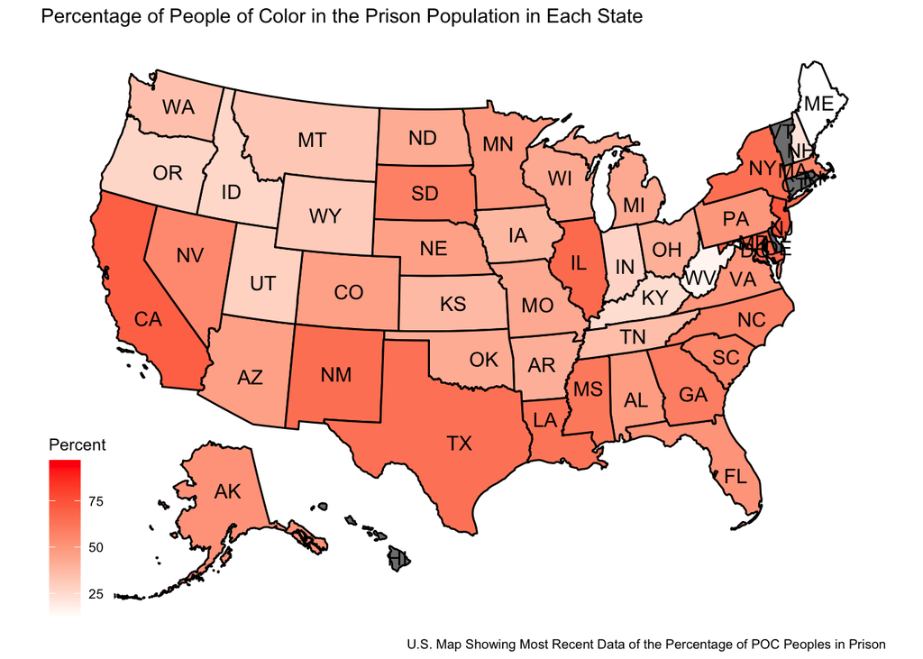